# FederalistPapers-part1

Ryan Wesslen

August 7, 2016

## Step 1: Set working directory and set up libraries

The first step is to set the working directory using the setwd command. The working directory is the folder that R will point to to either import new files (e.g. load a csv) or export new files.

```r
setwd("~/Dropbox/Federalist-Papers-Workshop")  #Linux
#setwd("C:/Users/rwesslen/Dropbox/Federalist-Papers-Workshop") #Windows
```

The next step is to install the R libraries (optional - only necessary if this is your first time). The install packages are commented out (#). To remove the comment, highlight the text and press CTRL + SHIFT + C.

Most of the libraries are downloaded from CRAN. CRAN is an open-source archive of R packages. Packages can be installed through CRAN with the “install.packages()” command.

Note, some packages (e.g. old or very new) sometimes may not be available on CRAN. In such cases, additional steps (e.g. pull from Github) may be required to download them.

```r
#install.packages("quanteda")
library(quanteda)
```

## Step 2: Load & explore the data and partition for training & test datasets

First, I load the csv file into my working directory. In this step, the file is converted to an R dataframe.

```r
papers <- read.csv("../data/federalist.csv", stringsAsFactors = F)
```

The next steps explore the size of the dataset, remove some redundant text (“To the People…” heading on all papers) and create an index to identify papers that will be in the training dataset (known Madison and Hamilton papers) and the test dataset (the 12 disputed papers).

```r
dim(papers)
```

```
## [1] 85  3
```

```r
table(papers$author)
```

```
##
##     BOTH DISPUTED HAMILTON      JAY  MADISON
##        3       12       51        5       14
```

```r
#       train/test: limit to Hamilton/Mad documents (drop Jay and Ham&Madison papers)
train <- which(papers$auth=="HAMILTON" | papers$auth=="MADISON")
length(train)   # 65
```

```
## [1] 65
```

```r
test <- which(papers$auth=="DISPUTED")
length(test)    # 12
```

```
## [1] 12
```

## Step 3: Data Pre-Processing

The next step starts the process of converting the string/characters of the text into word count vectors (columns) that will be used to create the Document-Term and Term-Document Matrices.

For our analysis, we will leverage the `quanteda` package. If you’re new to the package, check out [this great vignette](https://cran.r-project.org/web/packages/quanteda/vignettes/quickstart.html).

```r
library(quanteda)

# remove "To the People of the State of New York <l>"
papers$text <- substring(papers$text,45)

# remove html tags
tags <- c("<c>","<p>","<S>","<l>","<q>","<d>","<Q>")
for (i in tags){
  papers$text <- gsub(i," ",papers$text)
}

# build the corpus
myCorpus <- corpus(papers$text)

# add in the attributes about the papers (number, author, train/test flag)
docvars(myCorpus, "Number") <- papers$number
docvars(myCorpus, "Author") <- papers$author

# summarize the documents
summary(myCorpus, 5)
```

```
## Corpus consisting of 85 documents, showing 5 documents.
##
##   Text Types Tokens Sentences Number   Author
##  text1   663   1615         1      1 HAMILTON
##  text2   651   1668         2      2      JAY
##  text3   527   1443         1      3      JAY
##  text4   608   1641         2      4      JAY
##  text5   552   1339         1      5      JAY
##
## Source:  /home/whitesox/Dropbox/Federalist-Papers-Workshop/part1/* on x86_64 by whitesox
## Created: Wed Oct  5 23:09:04 2016
## Notes:
```

Now, let’s analyze the text. First, let’s examine word counts (total and unique):

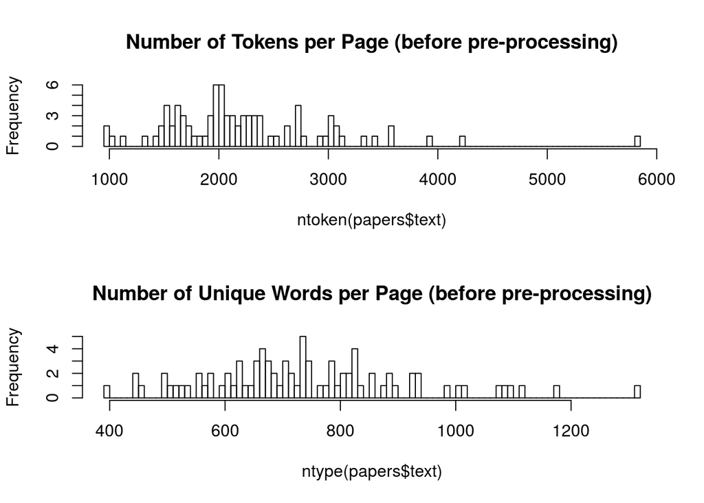

```r
par(mfrow=c(2,1))
hist(ntoken(papers$text), breaks = 100, main = "Number of Tokens per Page (before pre-processing)")
hist(ntype(papers$text), breaks = 100,  main = "Number of Unique Words per Page (before pre-processing)")
```

```r
par(mfrow=c(1,1))
```

We can also plot them across time (so x-axis is what number paper it is):

```r
tokenInfo <- summary(myCorpus)
```

```
## Corpus consisting of 85 documents.
##
##    Text Types Tokens Sentences Number   Author
##   text1   663   1615         1      1 HAMILTON
##   text2   651   1668         2      2      JAY
##   text3   527   1443         1      3      JAY
##   text4   608   1641         2      4      JAY
##   text5   552   1339         1      5      JAY
##   text6   837   2054         2      6 HAMILTON
##   text7   860   2305         1      7 HAMILTON
##   text8   785   2054         1      8 HAMILTON
##   text9   780   1989         1      9 HAMILTON
##  text10   882   2999         1     10  MADISON
##  text11   882   2505         3     11 HAMILTON
##  text12   820   2166         1     12 HAMILTON
##  text13   397    961         1     13 HAMILTON
##  text14   782   2150         1     14  MADISON
##  text15  1089   3086         1     15 HAMILTON
##  text16   750   2038         1     16 HAMILTON
##  text17   621   1565         1     17 HAMILTON
##  text18   830   2106         1     18     BOTH
##  text19   803   2047         1     19     BOTH
##  text20   673   1522         1     20     BOTH
##  text21   738   1995         2     21 HAMILTON
##  text22  1174   3572         1     22 HAMILTON
##  text23   658   1798         1     23 HAMILTON
##  text24   747   2007         2     24 HAMILTON
##  text25   734   1986         2     25 HAMILTON
##  text26   822   2385         1     26 HAMILTON
##  text27   554   1455         1     27 HAMILTON
##  text28   574   1606         2     28 HAMILTON
##  text29   793   2239         1     29 HAMILTON
##  text30   738   1967         1     30 HAMILTON
##  text31   636   1733         1     31 HAMILTON
##  text32   491   1486         1     32 HAMILTON
##  text33   567   1689         1     33 HAMILTON
##  text34   770   2213         1     34 HAMILTON
##  text35   735   2252         1     35 HAMILTON
##  text36   851   2740         2     36 HAMILTON
##  text37   939   2709         1     37  MADISON
```

[output cut: 37 more lines]

```
##  text75   682   1944         1     75 HAMILTON
##  text76   675   2303         1     76 HAMILTON
##  text77   683   1971         1     77 HAMILTON
##  text78   927   3064         1     78 HAMILTON
##  text79   452   1032         1     79 HAMILTON
##  text80   740   2451         1     80 HAMILTON
##  text81  1009   3929         1     81 HAMILTON
##  text82   494   1545         1     82 HAMILTON
##  text83  1319   5846         1     83 HAMILTON
##  text84  1120   4203         1     84 HAMILTON
##  text85   927   2711         1     85 HAMILTON
##
## Source:  /home/whitesox/Dropbox/Federalist-Papers-Workshop/part1/* on x86_64 by whitesox
## Created: Wed Oct  5 23:09:04 2016
## Notes:
```

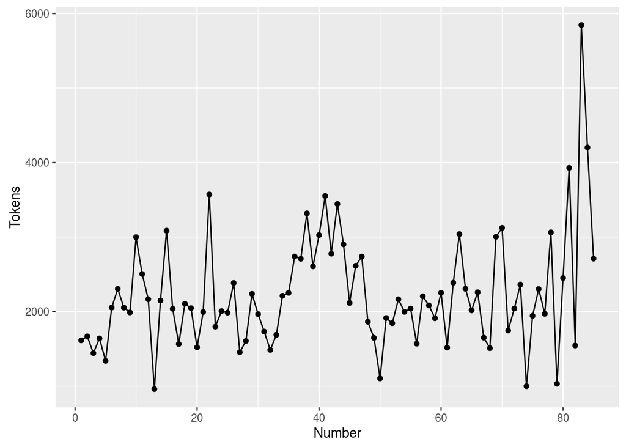

```r
if (require(ggplot2))
    ggplot(data=tokenInfo, aes(x=Number, y=Tokens, group=1)) + geom_line() + geom_point()
```

### Pre-Processing

Let’s now start the pre-processing.

First, let’s create a dfm (document-feature matrix) and look at the top 20 words:

```r
myDfm <- dfm(myCorpus)
topfeatures(myDfm, 20)
```

```
##   the    of    to   and    in     a    be  that    it    is which    by
## 17573 11630  6972  5080  4445  3984  3832  2788  2544  2190  2061  1745
##    as  this would  have  will   for    or   not
##  1720  1409  1277  1258  1256  1233  1231  1213
```

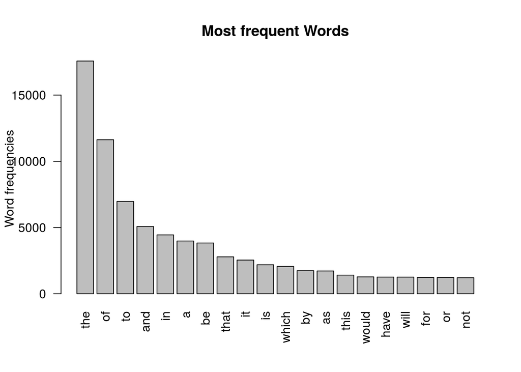

```r
barplot(topfeatures(myDfm, 20), las = 2, main ="Most frequent Words",ylab = "Word frequencies")
```

This is not surprising. The most common words are very “common” words like “the”, “of”, “to”, “and”. These words do not provide a lot of meaning as they’re used so frequently.

Let’s instead use a common list of stopwords and rerun our initial counts.

```r
myDfm <- dfm(myCorpus, ignoredFeatures = c(stopwords("english")))
topfeatures(myDfm, 20)
```

```
##         will       states   government          may        state
##         1256          850          829          812          702
##        power          one       people          can constitution
##          605          547          527          464          461
##         must         upon        union        every     national
##          446          387          362          350          340
##      federal        might        great    authority       public
##          324          322          291          290          283
```

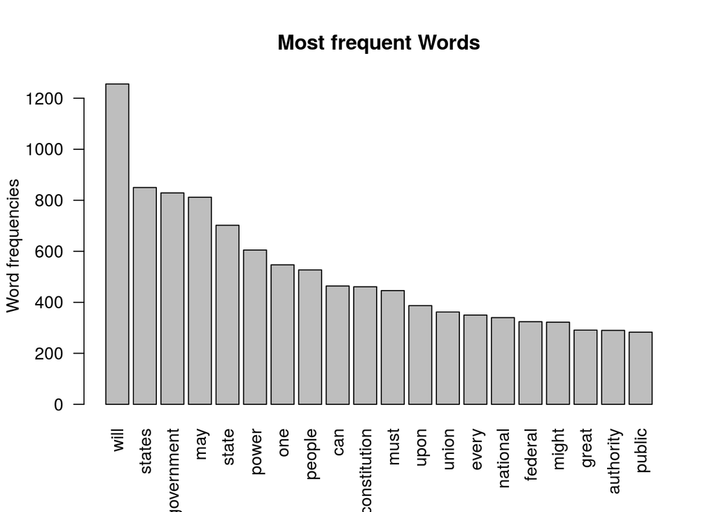

```r
barplot(topfeatures(myDfm, 20), las = 2, main ="Most frequent Words",ylab = "Word frequencies")
```

This is much better but not great. Let’s now use a word cloud to look beyond the top 20 words:

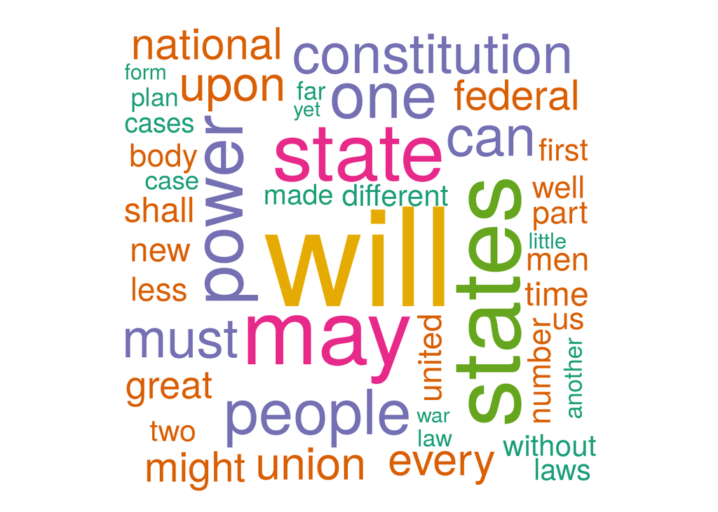

```r
library(RColorBrewer)
plot(myDfm, max.words = 100, colors = brewer.pal(6, "Dark2"), random.order = F, scale = c(8, .5))
```

Usually, at this point, it would be good to add more stop words and rerun our preprocessing.

Let’s add a longer list of words and rerun our counts:

```r
stopWords <- c("will","one","two","may","less","well","might","without","small","single","several","however","must","number","part","upon","consider","particular","place","true","shall","often","former","latter","want","can","everything","every","different","either","yet","made","now","publius","therefore","first","second","third","though","another","found","within","even","far","just","also","said","ever","three","four","still","little")

myDfm <- dfm(myCorpus, ignoredFeatures = c(stopwords("english"),stopWords), stem = F)

topfeatures(myDfm, 20)
```

```
##       states   government        state        power       people
##          850          829          702          605          527
## constitution        union     national      federal        great
##          461          362          340          324          291
##    authority       public      general       powers         time
##          290          283          262          255          249
##    executive          new       united          men      members
##          244          242          238          237          225
```

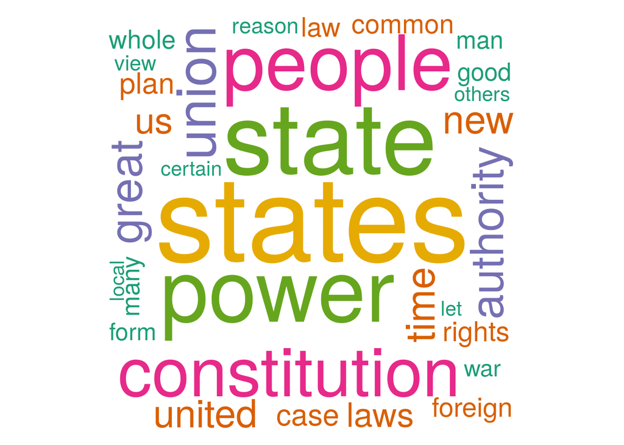

```r
plot(myDfm, max.words = 100, colors = brewer.pal(6, "Dark2"), random.order = F, scale = c(8, .5))
```

Good. Now we’re focusing more on specific words that relate to concepts rather than are indicative of writing style. Let’s keep this preprocessing and move to exploring the documents.

## Step 4: Exploratory Analysis with Similarity, Word Associations/Clustering and Comparison Word Cloud

First, let’s consider an application to measure the similarity of each paper.

### Application: Document Similarity

Let’s suppose you are an American studies history teacher. Your favorite Federalist paper is [Federalist #70](https://en.wikipedia.org/wiki/Federalist_No._70).

In this paper titled “The Executive Department Further Considered” written by Alexander Hamilton, Hamilton argues for a one-man executive branch led by the president.

Let’s now assume you want to recommend to your students the Federalist paper that is most closely related to Federalist #70. How can you do this?

You can use a **similarity** measure that quantifies how similar Federalist #70 is to all of the papers (by the word counts) and rank order all papers to find the most similar.

In the `quanteda` package, we use the the function `similarity` to find the top 5 most similar papers:

```r
similarity(myDfm, "text70", n=5, margin="documents", method = "correlation")
```

```
## similarity Matrix:
## $text70
## text77 text73 text48 text47 text71
## 0.4685 0.4618 0.4576 0.4261 0.4168
```

From this measure, we find that Federalist #77 is most similar to Federalist #70.

There’s also the great `dotchart` that can plot our results. Let’s instead explore the top 20 papers like Federalist #70.

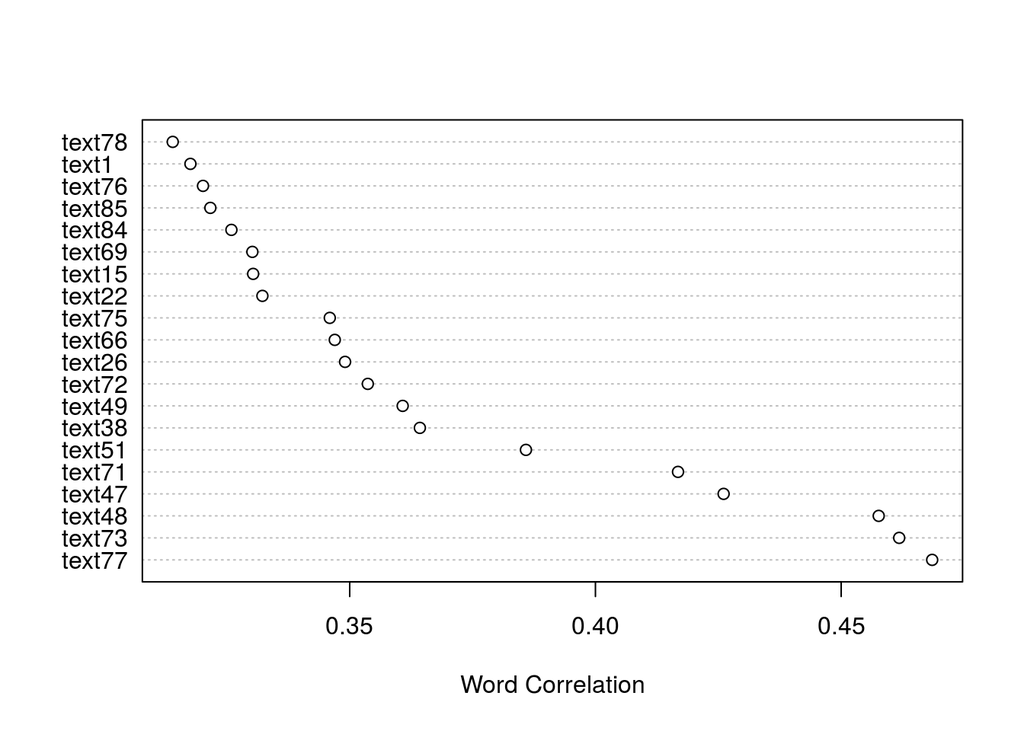

```r
paper70sim <- similarity(myDfm, "text70", n=20, margin="documents", method = "correlation")

dotchart(paper70sim$`text70`, xlab = "Word Correlation")
```

Further, correlation is but one measure of similarity. Other common ones like cosine similarity, Hellinger distance and (extended) Jaccard index are also available in the function.

```r
similarity(myDfm, "text70", n=5, margin="documents", method = "cosine")
```

```
## similarity Matrix:
## $text70
## text77 text73 text48 text71 text47
## 0.4892 0.4834 0.4750 0.4410 0.4377
```

```r
similarity(myDfm, "text70", n=5, margin="documents", method = "Hellinger")
```

```
## similarity Matrix:
## $text70
## text77 text22 text51 text48 text73
## 0.4774 0.4719 0.4714 0.4712 0.4710
```

```r
similarity(myDfm, "text70", n=5, margin="documents", method = "eJaccard")
```

```
## similarity Matrix:
## $text70
## text73 text48 text77 text38 text51
## 0.3110 0.3034 0.3019 0.2472 0.2467
```

### Word Associations

Next, I analyze word associations for a sample of words. The “findAssocs” function will take a given word (e.g., “germanic”) and given an association parameter (e.g., 0.85), and return the words that are in at least x% (association parameter) of the papers with the given word.

To run this analysis, we’ll need two non-CRAN packages.

```r
## Non CRAN packages, choose "n" for updates or else it may update a lot of other packages
#source("https://bioconductor.org/biocLite.R")
#biocLite("graph")
#biocLite("Rgraphviz")

library(graph); library(Rgraphviz);
```

So for example, the first call to the function will return all words that are in at least 70% of the papers that contain the word “commerce”.

```r
DTM <- as.DocumentTermMatrix(myDfm)

library(tm)
# Word Associations
findAssocs(DTM, "commerce", 0.7)
```

```
## $commerce
##       trade     traffic intercourse  commercial
##        0.82        0.80        0.76        0.70
```

```r
findAssocs(DTM, "debt", 0.8)
```

```
## $debt
##   extinguishment          liberal          seeming          deluged
##             0.88             0.84             0.83             0.83
##            tract        unsettled        undecided         cessions
##             0.83             0.83             0.83             0.83
##         amicable           ceased          reclaim        reversion
##             0.83             0.83             0.83             0.83
##          revoked    apportionment          wyoming        expecting
##             0.83             0.83             0.83             0.83
##         resigned           inside            vouch           attest
##             0.83             0.83             0.83             0.83
##    preponderated        dismember      perspective        favorably
##             0.83             0.83             0.83             0.83
##         escaping          sharing      preferences       settlement
##             0.83             0.83             0.83             0.83
##           keener             edge       denominate       consulting
##             0.83             0.83             0.83             0.83
##        unbridled        reprisals      impatiently           forego
##             0.83             0.83             0.83             0.83
##         remitted       metropolis        collision        afterward
##             0.83             0.83             0.83             0.83
##            alike      discharging procrastinations          clamour
##             0.83             0.83             0.83             0.83
##         agreeing           harder        sufferers     incumbrances
##             0.83             0.83             0.83             0.83
##      altercation         payments         outlived   recriminations
##             0.83             0.83             0.83             0.83
##       disgracing      retaliation       enormities      perpetrated
##             0.83             0.83             0.83             0.83
##         chastise          jarring     machinations               et
##             0.83             0.83             0.83             0.83
##          impera1            motto            hates          publish
##             0.83             0.83             0.83             0.83
##          tuesday           packet         thursday       advertiser
##             0.83             0.83             0.83             0.83
##          payment
##             0.81
```

```r
findAssocs(DTM, "slavery", 0.7)
```

```
## $slavery
##      sincerity      vengeance       neighbor         chains   amphictyonic
##           1.00           0.81           0.81           0.74           0.70
##        delphos      violators   sacrilegious     despoilers     tyrannized
##           0.70           0.70           0.70           0.70           0.70
##    demosthenes        leuctra        thebans         persia      eternally
##           0.70           0.70           0.70           0.70           0.70
##      hirelings         xerxes     vigorously          piece         center
##           0.70           0.70           0.70           0.70           0.70
##     satellites          milot     courageous     admonished        availed
##           0.70           0.70           0.70           0.70           0.70
##        persian    reformation       inflated        hatreds    dissentions
##           0.70           0.70           0.70           0.70           0.70
##       phocians       ploughed    consecrated         apollo      offenders
##           0.70           0.70           0.70           0.70           0.70
##         decree         philip       fostered         gladly       stricter
##           0.70           0.70           0.70           0.70           0.70
##        praetor     lacedaemon    philopoemen      witnessed       tempered
##           0.70           0.70           0.70           0.70           0.70
##        reigned      alexander     macedonian          shame       reunited
##           0.70           0.70           0.70           0.70           0.70
##        cutting   peloponnesus       hindered       stopping         caught
##           0.70           0.70           0.70           0.70           0.70
##         rising           damp          egypt          syria      cleomenes
##           0.70           0.70           0.70           0.70           0.70
##     unprovoked       egyptian         syrian   supplicating  intermeddling
##           0.70           0.70           0.70           0.70           0.70
##         abject        messene      aetolians     invitation          broke
##           0.70           0.70           0.70           0.70           0.70
##    callicrates     inveigling       liberty1           torn    distraction
##           0.70           0.70           0.70           0.70           0.70
##     completing            cut         achaia       groaning    illustrates
##           0.70           0.70           0.70           0.70           0.70
##      incidents    proficiency     organizing         arming   disciplining
##           0.70           0.70           0.70           0.70           0.70
##       training      untenable          posse      comitatus    incoherence
##           0.70           0.70           0.70           0.70           0.70
##     abolishing      illogical        charity        viewing        deliver
##           0.70           0.70           0.70           0.70           0.70
##      discourse     expertness       yeomanry     evolutions        endured
```

[output cut: 10 more lines]

```
##           0.70           0.70           0.70           0.70           0.70
##     represents   transforming        marched       kentucky      champlain
##           0.70           0.70           0.70           0.70           0.70
##     militiamen          d'ors         ducats      prostrate      contumacy
##           0.70           0.70           0.70           0.70           0.70
##    transported    haughtiness     virginians           rave       conceits
##           0.70           0.70           0.70           0.70           0.70
##    absurdities        whither       hopeless       riveting        foolish
##           0.70           0.70           0.70           0.70           0.70
##  intrenchments       incensed         stride       exciting    detestation
##           0.70           0.70           0.70           0.70           0.70
##     disgustful     execration        ravings   incendiaries    enthusiasts
##           0.70           0.70           0.70           0.70           0.70
##         supine       listless
##           0.70           0.70
```

```r
findAssocs(DTM, "montesquieu", 0.65)
```

```
## $montesquieu
##      passages   corresponds        author       mixture        beauty
##          0.76          0.76          0.74          0.74          0.73
## selfappointed         homer      didactic          epic        poetry
##          0.73          0.73          0.73          0.73          0.73
##      immortal          bard        critic        mirror    elementary
##          0.73          0.73          0.73          0.73          0.73
##  conclusively          lest         mixes     presiding    expressing
##          0.73          0.73          0.73          0.73          0.73
##          goes   appointable     removable        blends     surrogate
##          0.73          0.73          0.73          0.73          0.73
##       officio   triennially     displaced        refers      sheriffs
##          0.73          0.73          0.73          0.73          0.73
##      captains organizations     exemplify      justices    department
##          0.73          0.73          0.73          0.70          0.68
##       totally      insisted
##          0.66          0.65
```

```r
findAssocs(DTM, "germanic", 0.85)
```

```
## $germanic
##       imperial   christianity         franks          gauls    charlemagne
##           0.97           0.95           0.95           0.95           0.95
##    descendants          diets       declined        suabian       austrian
##           0.95           0.95           0.95           0.95           0.95
##       eleventh       emperors        symbols    decorations          aulic
##           0.95           0.95           0.95           0.95           0.95
##      assessing     fortresses        retreat     disturbers    electorates
##           0.95           0.95           0.95           0.95           0.95
##   universities       receives         parade      nerveless  fermentations
##           0.95           0.95           0.95           0.95           0.95
##     intrusions     inbecility         misery      sixteenth         flight
##           0.95           0.95           0.95           0.95           0.95
##       prisoner         saxony         pitted          pages       describe
##           0.95           0.95           0.95           0.95           0.95
##     negotiated       preceded       retiring         winter       quarters
##           0.95           0.95           0.95           0.95           0.95
##    defectively          badly   contumacious      miniature        thuanus
##           0.95           0.95           0.95           0.95           0.95
##      donawerth         suabia            abb             st          croix
##           0.95           0.95           0.95           0.95           0.95
##        bavaria     antiquated      reannexed        domains     disjointed
##           0.95           0.95           0.95           0.95           0.95
##     heriditary      repellant    strengthens    preeminence   perpetuating
##           0.95           0.95           0.95           0.95           0.95
##      disburden insignificancy    homogeneous    suppressing   accomodating
##           0.95           0.95           0.95           0.95           0.95
##     definitive         victor        amadeus          savoy       mediator
##           0.95           0.95           0.95           0.95           0.95
##         sprang     protestant       catholic       bailages          berne
##           0.95           0.95           0.95           0.95           0.95
##        luzerne        pfeffel         nouvel          abreg        chronol
##           0.95           0.95           0.95           0.95           0.95
##         l'hist    d'allemagne      indemnify           diet         empire
##           0.95           0.95           0.95           0.92           0.91
##        emperor        chamber            ban        cantons        germany
##           0.91           0.90           0.90           0.89           0.86
##         circle
##           0.86
```

This step is helpful because it can identify words that (1) tend to form topics/clusters and/or (2) words that make up a larger bigram or trigram entity structure.

The plot provides words that (1) have a frequency larger than 200 and show correlations for words with at least a 25% association. This plot too is helpful for determining clusters and/or bigram/trigram structure for the most common words.

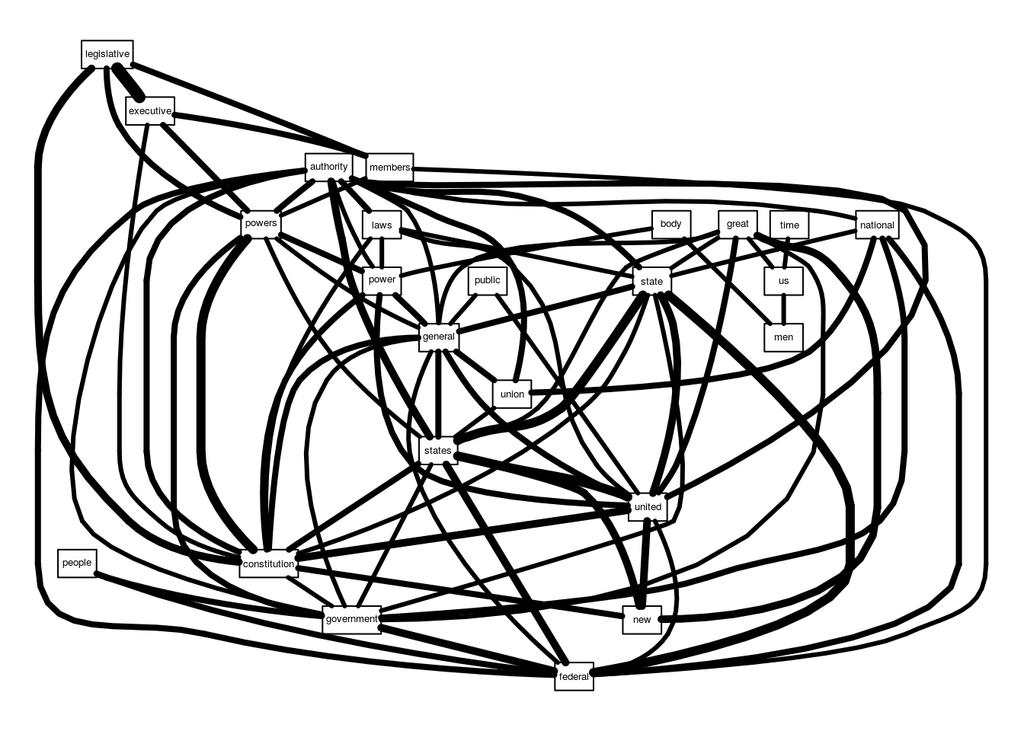

```r
#       queries of co-occurences
freq.terms <- findFreqTerms(DTM, lowfreq = 200)
term.freq <- rowSums(as.matrix(DTM))
term.freq <- subset(term.freq, term.freq >= 200)

plot(DTM, term = freq.terms, corThreshold = 0.25, weighting = T)
```

```r
dev.off()
```

### Word Clustering

The next step uses [hierarchal clustering](https://en.wikipedia.org/wiki/Hierarchical_clustering) to identify clusters/patterns in words that tend to co-occur together.

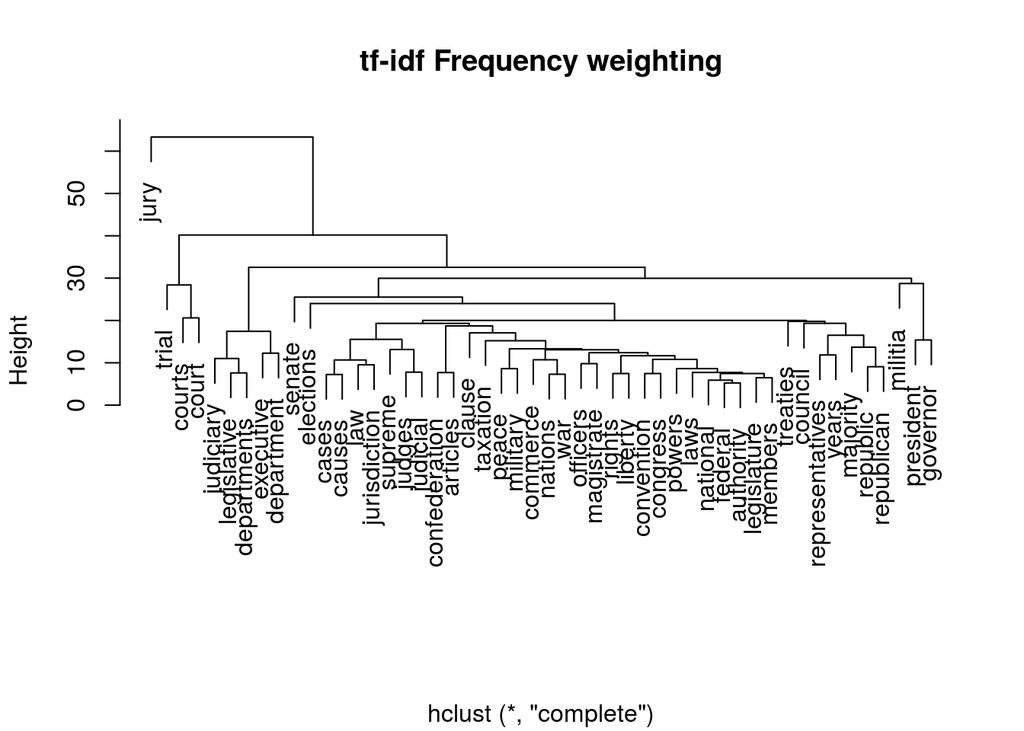

```r
# word dendrogram with tf-idf weighting
wordDfm <- sort(weight(myDfm, "tfidf"))
wordDfm <- t(wordDfm)[1:50,]  # because transposed
wordDistMat <- dist(wordDfm)
wordCluster <- hclust(wordDistMat)
plot(wordCluster, xlab="", main="tf-idf Frequency weighting")
```

### Document Clustering

Further, we can transpose the matrix and cluster instead on the documents to find how similar the documents are to one another.

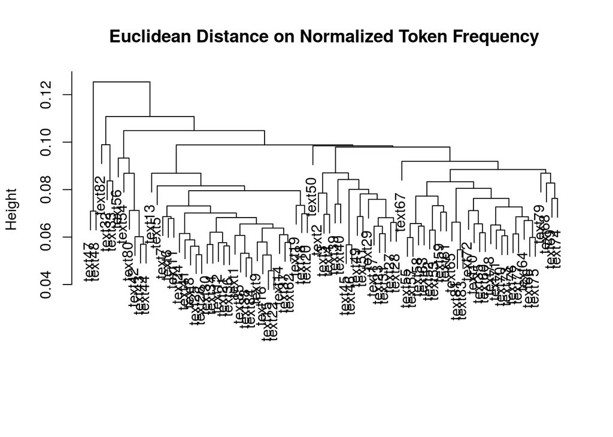

```r
myDfm <- trim(myDfm, minCount=5, minDoc=3)
# hierarchical clustering - get distances on normalized dfm
myDistMat <- dist(as.matrix(weight(myDfm, "relFreq")))
# hiarchical clustering the distance object
myCluster <- hclust(myDistMat)
# plot as a dendrogram
plot(myCluster, xlab = "", sub = "", main = "Euclidean Distance on Normalized Token Frequency")
```

### Comparison Word Clouds

Remember, our ultimate task is to predict the disputed Federalist Papers. One exploratory technique we can use is the *comparison* word cloud, which compares the relative frequency of words by the author.

First, since we’re only interested in papers written by Hamilton and Madison, let’s remove John Jay’s papers and the papers written by both Hamilton and Madison.

```r
newCorpus <- subset(myCorpus, Author %in% c("HAMILTON","MADISON","DISPUTED"))
```

To create a comparison word cloud, we need to create a grouped dfm using the `group` parameter.

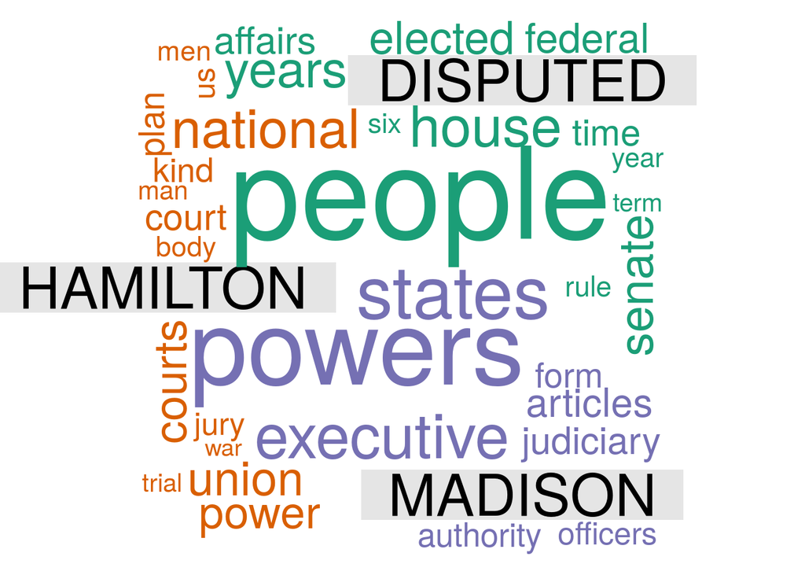

```r
myGroupDfm <- dfm(newCorpus, groups = "Author", ignoredFeatures = c(stopwords("english"),stopWords), stem = F)

plot(myGroupDfm, comparison = T, max.words = 100, colors = brewer.pal(6, "Dark2"), random.order = F, scale = c(8, .5))
```

## Advanced Steps: Additional Stop Words, Stemming and Bigrams

As seen previously, the results are largely dominated by several words that are very frequent throughout the entire corpus (words like government or state). Worse, several of these words mean the same thing but are in different forms (e.g., government and governments).

Also, several combination of words make up entities that don’t mean the same when the words are separated (e.g. Great + Britain, or New + York). Without controlling for these complexities, initial text mining analysis can be vague.

In order to improve our results, I reran pre-processing steps to remove common stop words, stem words and add in bigrams into the analysis.

After running these steps, consider rerunning the visualizations and note the differences. How important is pre-processing?

```r
# Additional Stop words
stopWords <- c(stopWords,"federal","members","national","union","united","general","government","governments","power","powers","state","states","people","constitution","constitutions")

myDfm <- dfm(myCorpus, ignoredFeatures = c(stopwords("english"),stopWords), stem = T, ngrams = c(1,3))

topfeatures(myDfm, 20)
```

```
##     author     object       case        law     execut      great
##        397        378        353        352        347        316
##   interest       time     public     repres legislatur       bodi
##        312        304        290        276        273        262
##      right     legisl        new      natur        men     reason
##        260        255        242        239        237        234
##      court    subject
##        233        226
```

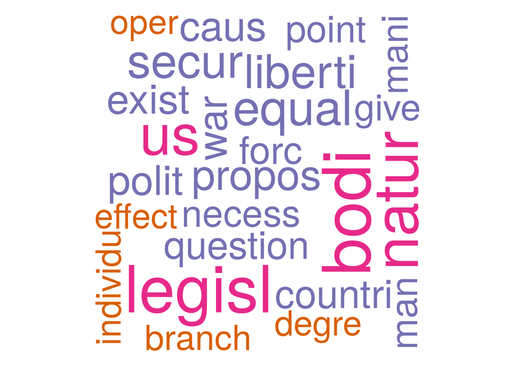

```r
plot(myDfm, max.words = 100, colors = brewer.pal(6, "Dark2"), scale = c(8, .5))
```